# RepData_Assignment1

Mahesh Sachdev

May 14, 2016

# Reproducible Research Assignment

## Loading and preprocessing the data

```r
act <- read.csv("activity.csv",header=TRUE,as.is=TRUE)
act$date <- as.Date(act$date,"%Y-%m-%d")
str(act)
```

```
## 'data.frame':    17568 obs. of  3 variables:
##  $ steps   : int  NA NA NA NA NA NA NA NA NA NA ...
##  $ date    : Date, format: "2012-10-01" "2012-10-01" ...
##  $ interval: int  0 5 10 15 20 25 30 35 40 45 ...
```

## What is mean total number of steps taken per day?

- Calculate the total number of steps taken per day

```r
dailyAct <- aggregate(act$steps,by=list(act$date),sum,na.rm=TRUE)
names(dailyAct) <- c("Date","TotalSteps")
str(dailyAct)
```

```
## 'data.frame':    61 obs. of  2 variables:
##  $ Date      : Date, format: "2012-10-01" "2012-10-02" ...
##  $ TotalSteps: int  0 126 11352 12116 13294 15420 11015 0 12811 9900 ...
```

- Make a histogram of the total number of steps taken each day

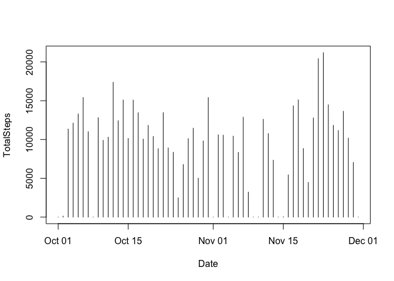

```r
plot(TotalSteps~Date,dailyAct,type="h")
```

- Calculate and report the mean and median of the total number of steps taken per day

```r
mean(dailyAct$TotalSteps)
```

```
## [1] 9354.23
```

```r
median(dailyAct$TotalSteps)
```

```
## [1] 10395
```

## What is the average daily activity pattern?

- Calculate the average number of steps taken across the 5-minute interval (x-axis)

```r
intervalAct <- aggregate(act,by=list(act$interval),mean,na.rm=TRUE)
str(intervalAct)
```

```
## 'data.frame':    288 obs. of  4 variables:
##  $ Group.1 : int  0 5 10 15 20 25 30 35 40 45 ...
##  $ steps   : num  1.717 0.3396 0.1321 0.1509 0.0755 ...
##  $ date    : Date, format: "2012-10-31" "2012-10-31" ...
##  $ interval: num  0 5 10 15 20 25 30 35 40 45 ...
```

- Make a time series plot (i.e. 𝚝𝚢𝚙𝚎 = “𝚕”) of the 5-minute interval (x-axis) and the average number of steps taken, averaged across all days (y-axis)

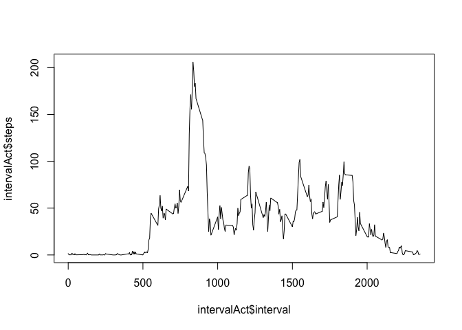

```r
plot(intervalAct$interval,intervalAct$steps,type="l")
```

- Which 5-minute interval, on average across all the days in the dataset, contains the maximum number of steps?

—–> Interval 835 contains the maximum number of steps (206.1698113) when averaged across all days.

## Impute missing values

- Calculate and report the total number of missing values in the dataset (i.e. the total number of rows with 𝙽𝙰s)

```r
sum(is.na(act))
```

```
## [1] 2304
```

- Fill in the missing values with the mean for the interval averaged across all days

```r
actImp <- transform(act, steps = ifelse(is.na(act$steps), intervalAct$steps, act$steps))
sum(is.na(actImp))
```

```
## [1] 0
```

- Make a histogram of the total number of steps taken each day (with imputed data)

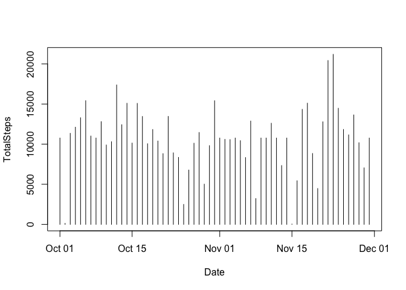

```r
dailyActImp <- aggregate(actImp$steps,by=list(act$date),sum,na.rm=TRUE)
names(dailyActImp) <- c("Date","TotalSteps")
plot(TotalSteps~Date,dailyActImp,type="h")
```

- Calculate and report the mean and median total number of steps taken per day.

```r
mean(dailyActImp$TotalSteps)
```

```
## [1] 10766.19
```

```r
median(dailyActImp$TotalSteps)
```

```
## [1] 10766.19
```

## Are there differences in activity patterns between weekdays and weekends?

- Create a new factor variable in the dataset with two levels – “weekday” and “weekend” indicating whether a given date is a weekday or weekend day.

```r
actImp$isWeekend <- factor(ifelse(weekdays(actImp$date)=="Saturday" | weekdays(actImp$date)=="Sunday","Weekend","Weekday"))
```

- Make a panel plot containing a time series plot (i.e. 𝚝𝚢𝚙𝚎 = “𝚕”) of the 5-minute interval (x-axis) and the average number of steps taken, averaged across all weekday days or weekend days (y-axis).

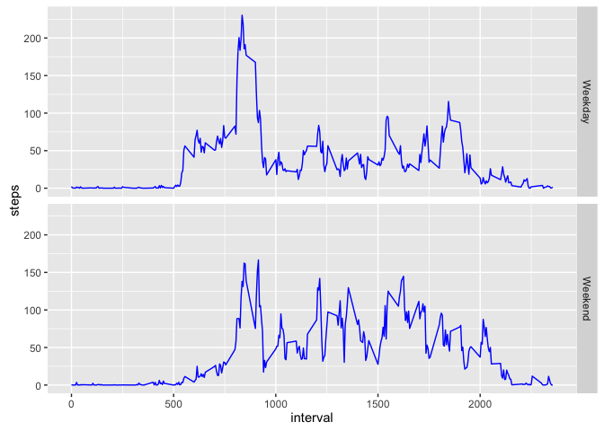

```r
intervalActW <- aggregate(steps ~ interval + isWeekend,actImp,mean)

ggplot(intervalActW, aes(x = interval, y = steps)) + facet_grid(isWeekend ~ .) + geom_line(colour = "blue")
```